# Data Visualization

# 1 Creation of simple scatter plot

To create a simple scatter plot using R, you can use ggplot() function with the dataset name as argument and geom_point() geom function with aesthetic (aes()) taking the argument of data to be plotted on each axis.

```r
#Simple graph
dim(mpg)
```

```
## [1] 234  11
```

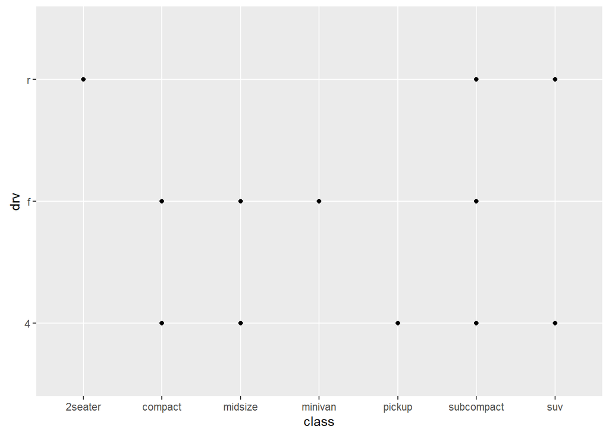

```r
ggplot(data = mpg) +
  geom_point(mapping = aes(x = class, y = drv))
```

## 1.1 Aesthetics

Aesthetics aes() function allows to modify the appearance of the geoms (point in the example below).

- color: change the color of geom
- size: affect the size of geom
- alpha: affect the level of transparency
- shape: change the type of shape (for certain type of geom)
- linetype: change the type of the line (with geom_smooth geom in the example below)

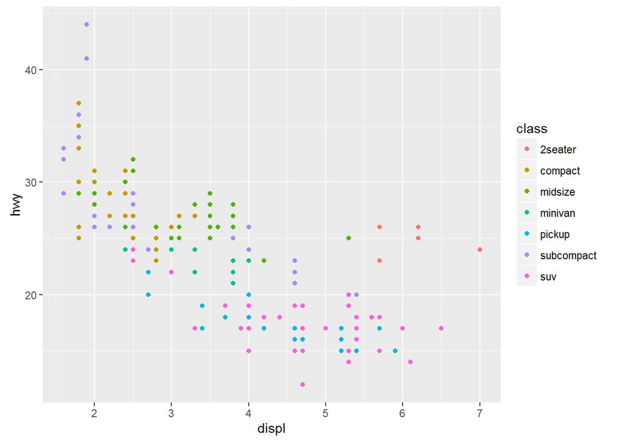

```r
#Using aesthetic to change point appearance (categorical)

ggplot(data = mpg) +
  geom_point(mapping = aes(x = displ, y = hwy,color=class))
```

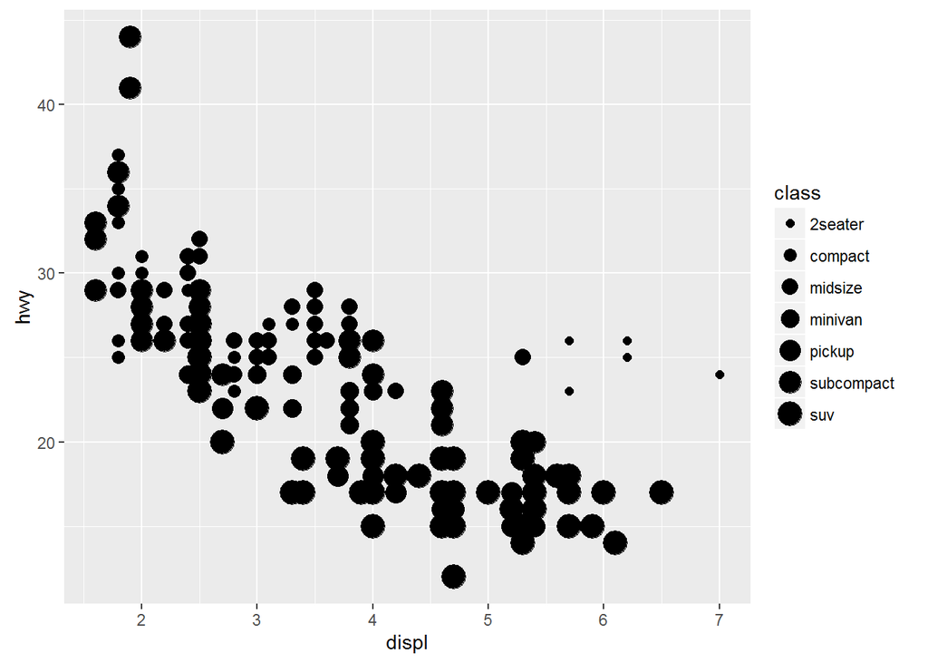

```r
ggplot(data = mpg) +
  geom_point(mapping = aes(x = displ, y = hwy,size=class))
```

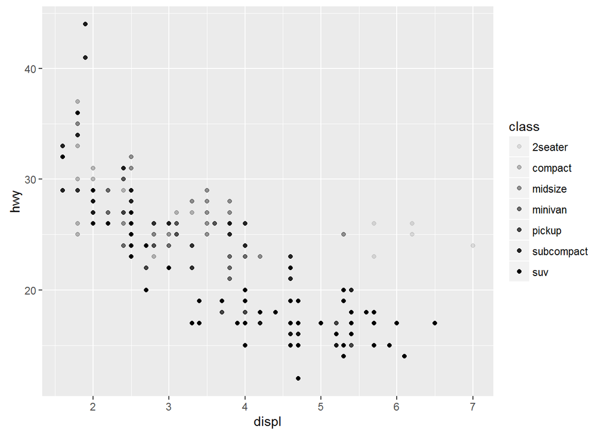

```r
ggplot(data = mpg) +
  geom_point(mapping = aes(x = displ, y = hwy,alpha=class))
```

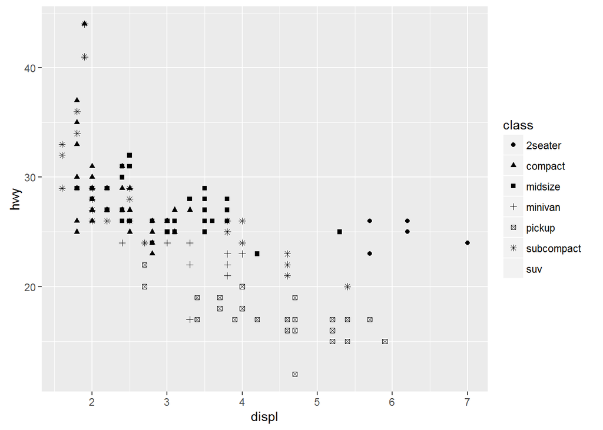

```r
ggplot(data = mpg) +
  geom_point(mapping = aes(x = displ, y = hwy,shape=class))
```

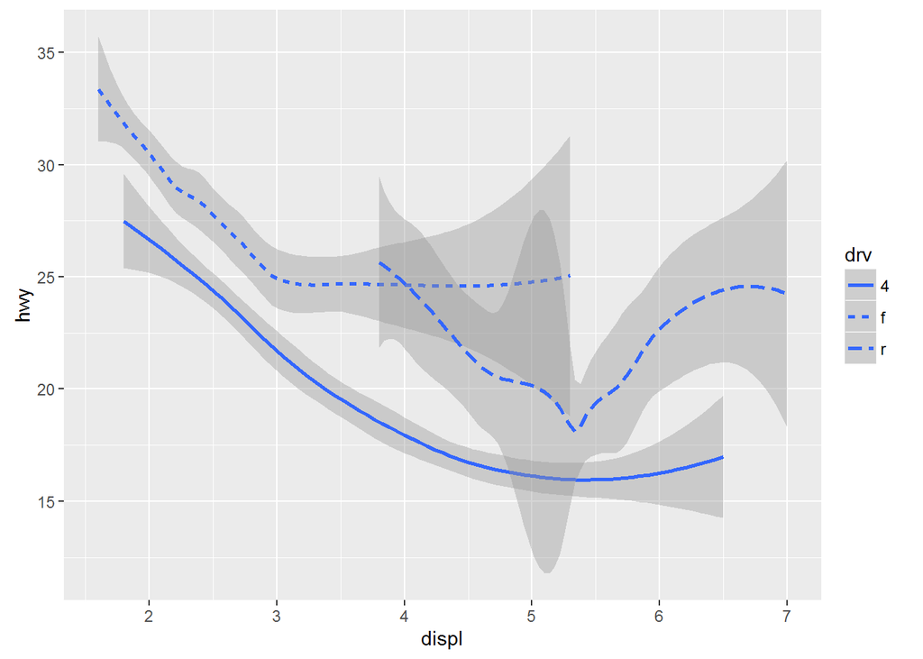

```r
#Different line by cat variables using linetype in aesthetic
ggplot(data = mpg,aes(x = displ, y = hwy, linetype = drv)) +
  geom_smooth()
```

These parameters can be mapped to categorical or continuous variables.

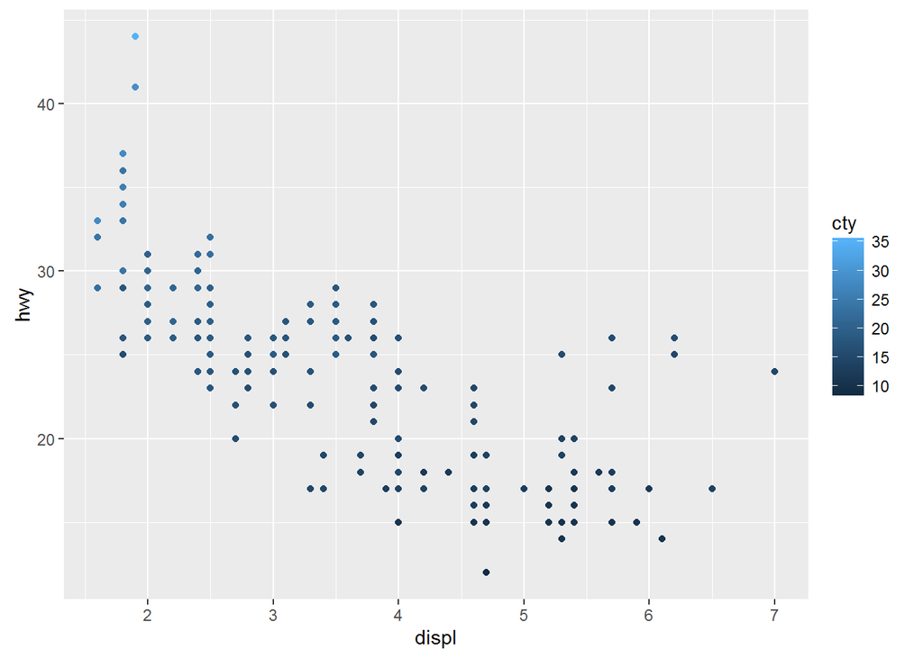

```r
#Using aesthetic to change point appearance (continuous)
ggplot(data = mpg) +
  geom_point(mapping = aes(x = displ, y = hwy,color=cty))
```

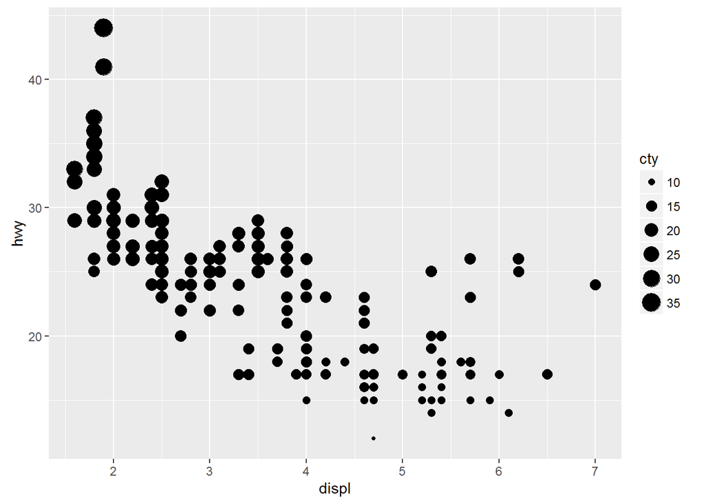

```r
ggplot(data = mpg) +
  geom_point(mapping = aes(x = displ, y = hwy,size=cty))
```

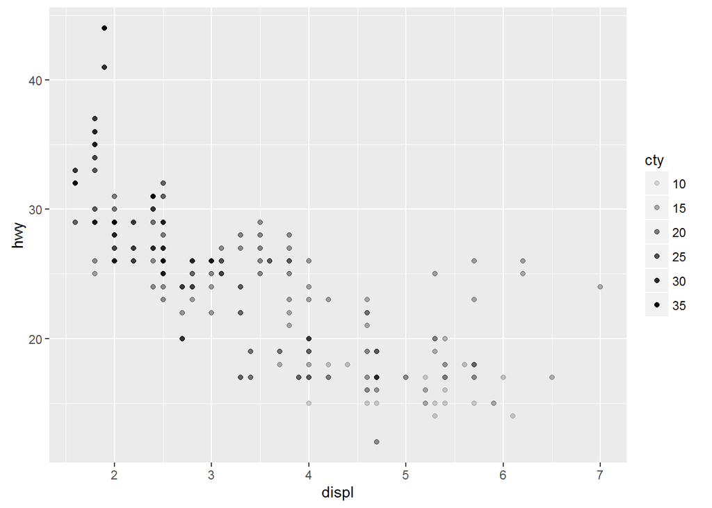

```r
ggplot(data = mpg) +
  geom_point(mapping = aes(x = displ, y = hwy,alpha=cty))
```

# 2 Using facets

Facets can be used in conjunction with ggplot to plot separately the data according to catagorical variables.

## 2.1 One variable

- facet_wrap: display the different graphs in rows
- facet_grid: display the different graphs in rows or in column

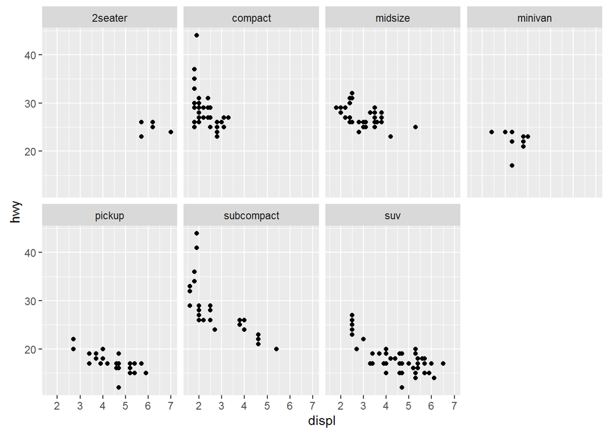

```r
#Two rows
ggplot(data = mpg) +
  geom_point(mapping = aes(x = displ, y = hwy)) +
  #nrow option allows to control the number of rows in the output
  facet_wrap(~ class, nrow = 2)
```

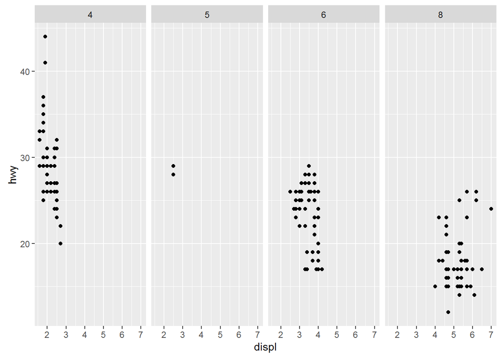

```r
#One row
ggplot(data = mpg) +
  geom_point(mapping = aes(x = displ, y = hwy)) +
  facet_grid(. ~ cyl)
```

## 2.2 Two variables

Facets can be used by combining two different categorical variables in facet_grid() function.

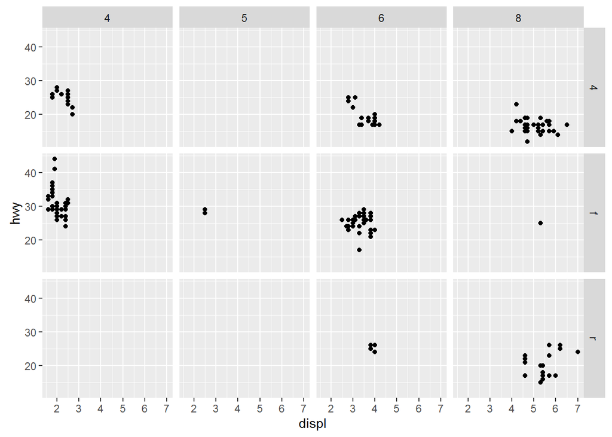

```r
ggplot(data = mpg) +
  geom_point(mapping = aes(x = displ, y = hwy)) +
  facet_grid(drv ~ cyl)
```

# 3 Using different geoms

- geom_point(): scatter plot
- geom_smooth(): fitted curve

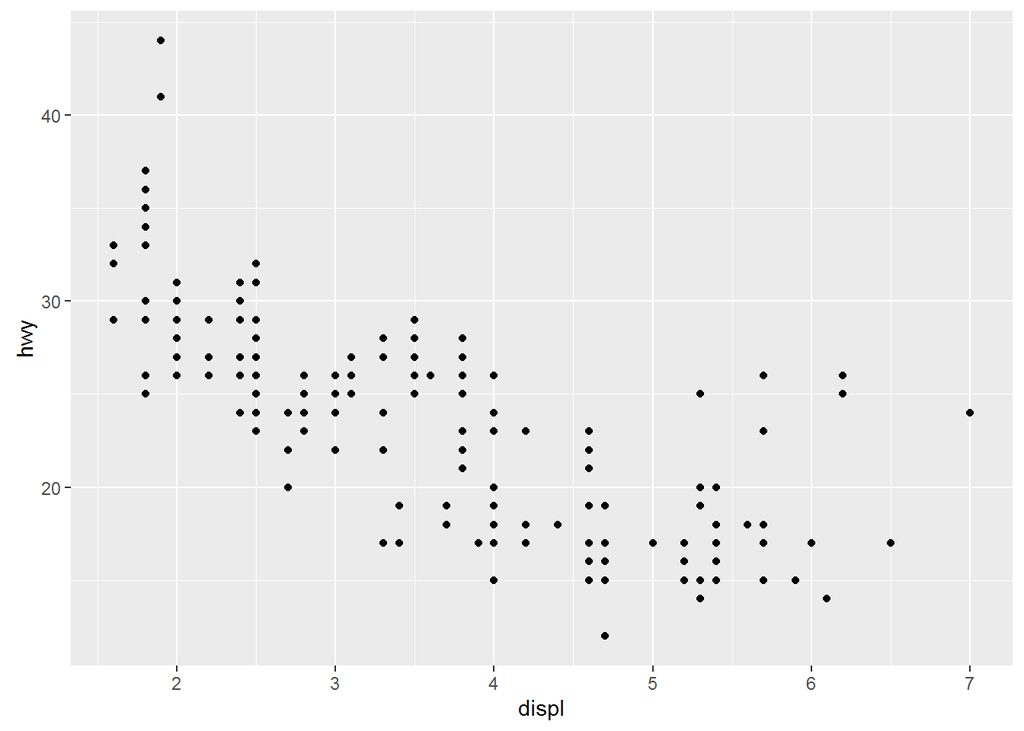

```r
# Scatter plot
ggplot(data = mpg) +
  geom_point(mapping = aes(x = displ, y = hwy))
```

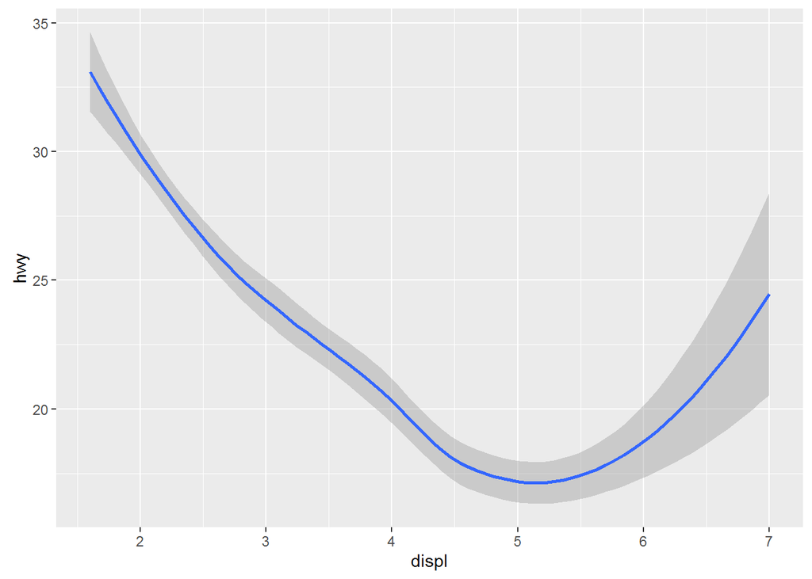

```r
# Smoothing
ggplot(data = mpg) +
  geom_smooth(mapping = aes(x = displ, y = hwy))
```

The following options can be used to plot the data for different groups when using geom_smooth():

- color: plot one curve by group (different colors)
- group: plot one curve by group

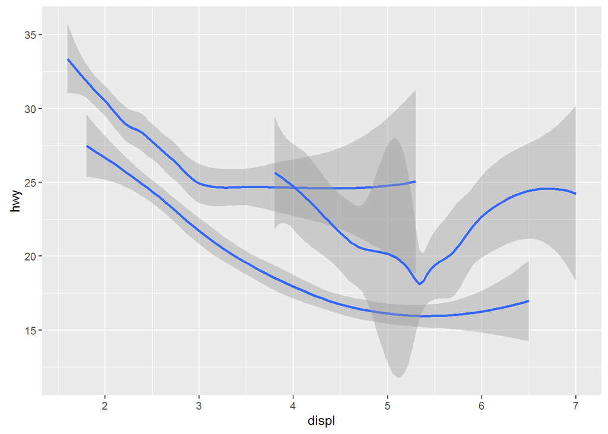

```r
#Plotting curves by group variable
ggplot(data = mpg) +
  geom_smooth(mapping = aes(x = displ, y = hwy, group = drv))
```

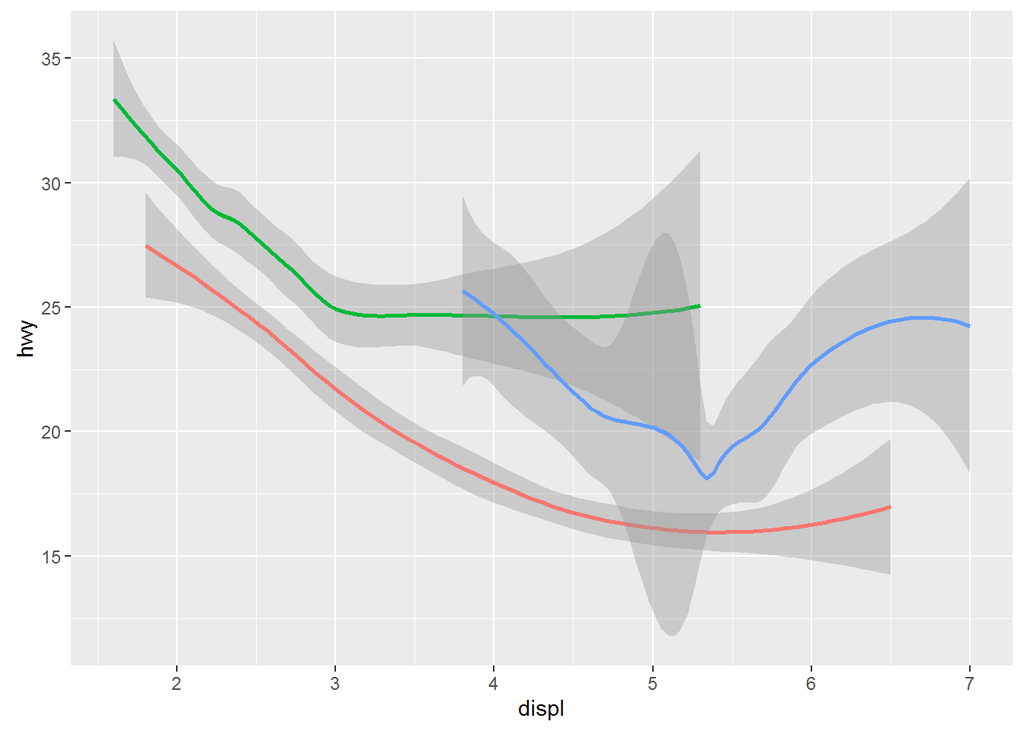

```r
ggplot(data = mpg) +
  geom_smooth(
    mapping = aes(x = displ, y = hwy, color = drv),
    show.legend = FALSE
  )
```

# 4 Different geoms in a same plot

It is possible to use different combinations of geoms and display it together.

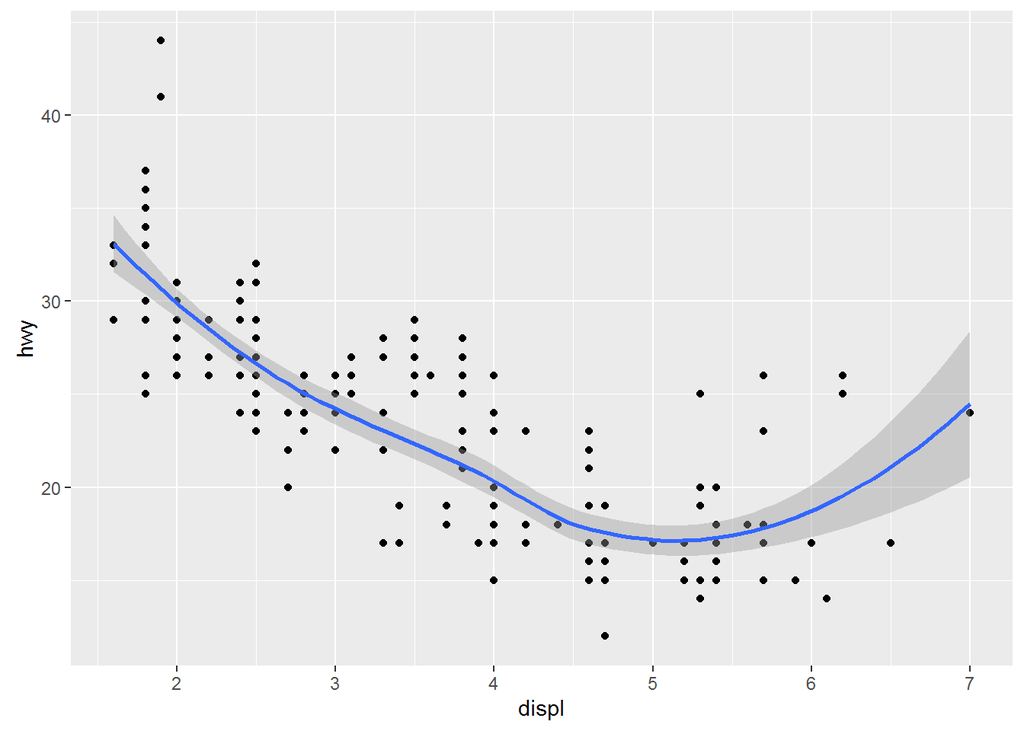

```r
#Combination of point and smooth geoms
ggplot(data = mpg) +
  geom_point(mapping = aes(x = displ, y = hwy)) +
  geom_smooth(mapping = aes(x = displ, y = hwy))
```

# 5 Global mapping/Local mapping

Global mapping allocates parameters to all geoms but local mapping (*i.e* declared in geom function) overrides global mapping. It can be used to plot different data within a same plot.

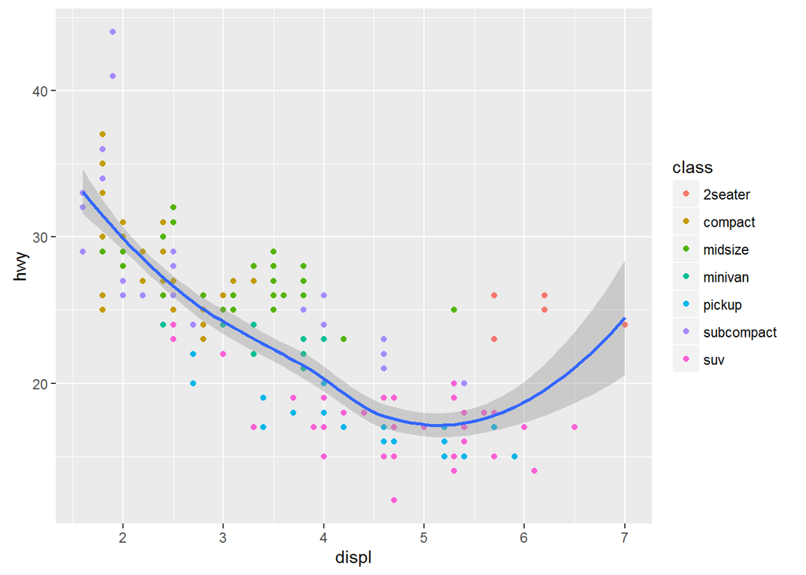

```r
#Global mapping
ggplot(data = mpg, mapping = aes(x = displ, y = hwy)) +
#Local mapping
  geom_point(mapping = aes(color = class)) +
  geom_smooth()
```

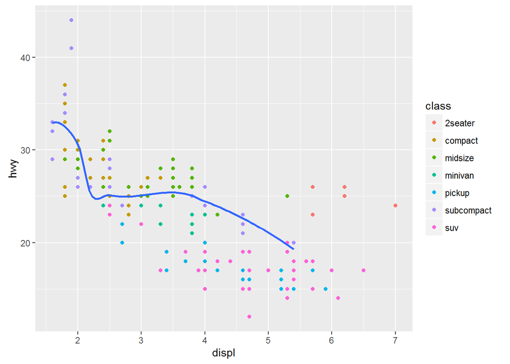

```r
#Subset in local mapping
ggplot(data = mpg, mapping = aes(x = displ, y = hwy)) +
  geom_point(mapping = aes(color = class)) +
  geom_smooth(data = filter(mpg, class == "subcompact"), se = FALSE)
```

# 6 Histogram

Histogram can be plotted using histogram geoms (geom_histogram() function).

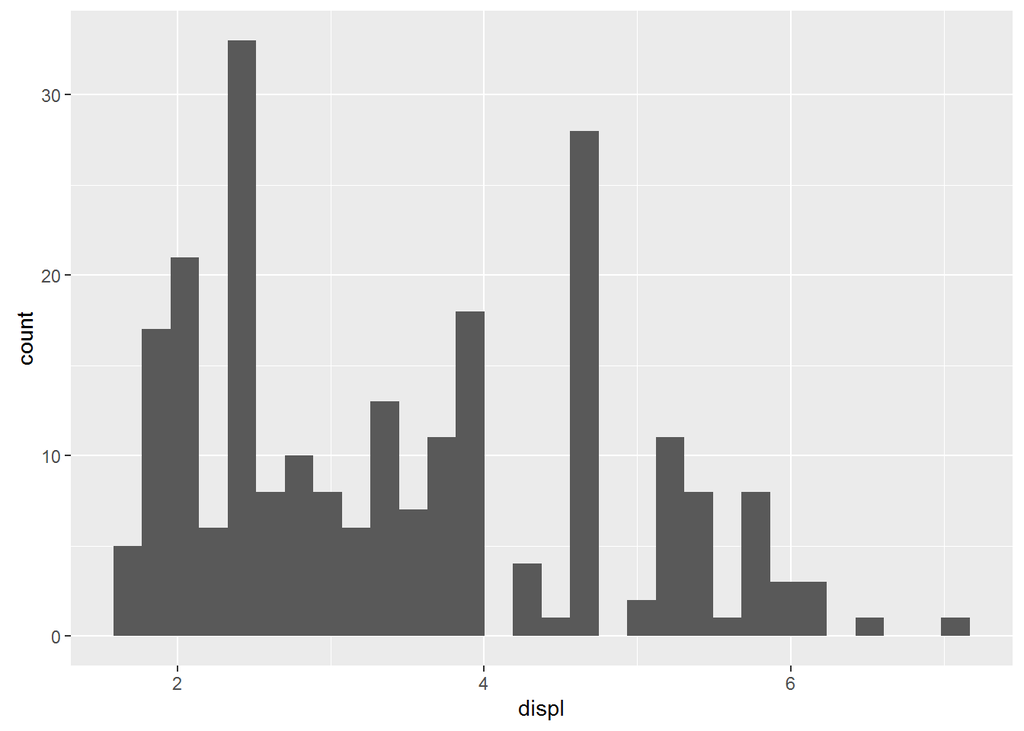

```r
ggplot(data = mpg, mapping = aes(x = displ)) +
  geom_histogram()
```

# 7 Bar graph with calculated values

Another option to plot histograms is to create a dataset with respective frequencies by group and then use the geom_bar() geom function.

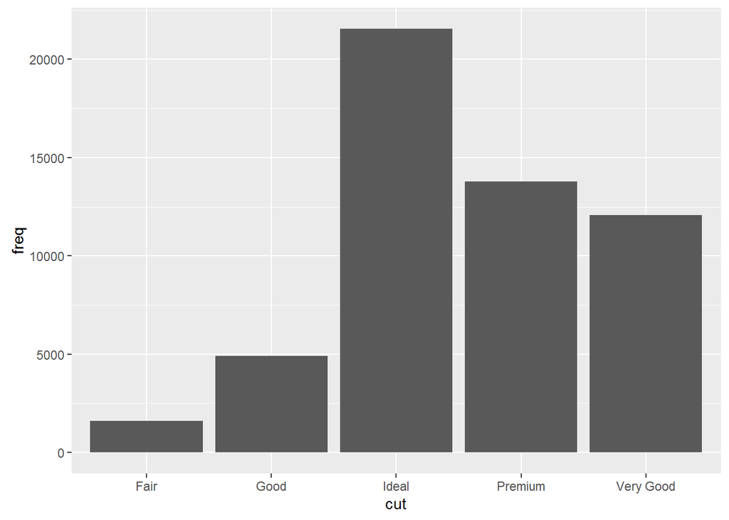

```r
#Data with frequency by a define categorical variable (tibble data frame)
demo <- tribble(
  ~cut,         ~freq,
  "Fair",       1610,
  "Good",       4906,
  "Very Good",  12082,
  "Premium",    13791,
  "Ideal",      21551
)

#Plotting the frequencies by group
ggplot(data = demo) +
  geom_bar(mapping = aes(x = cut, y = freq), stat = "identity")
```

Overall percentage using bar chart can be displayed by specifiying “y=..prop..”.

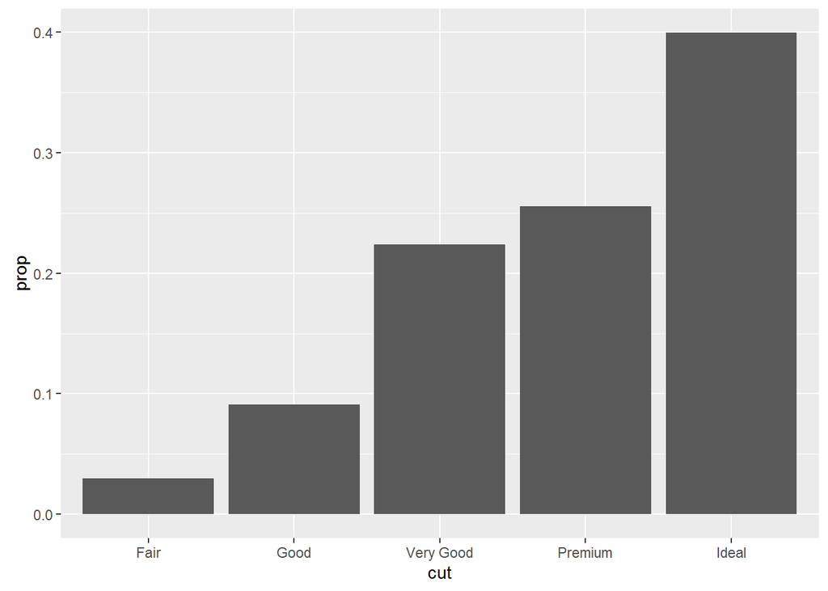

```r
#Plotting the percentage by group (overall percentage)
ggplot(data = diamonds) +
  geom_bar(mapping = aes(x = cut, y = ..prop.., group = 1))
```

# 8 Summary statistics

Summary statistics (quantile, etc…) displayed can be specified using stat_summary() function in “fun.” arguments.

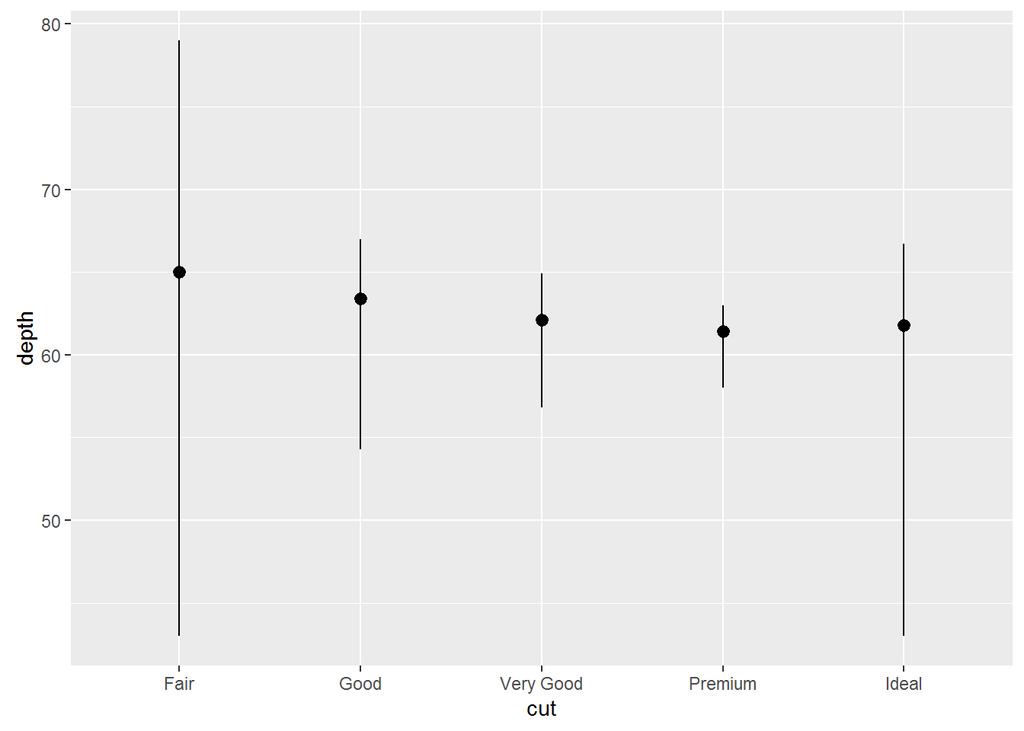

```r
#Summary
ggplot(data = diamonds) +
  stat_summary(
    mapping = aes(x = cut, y = depth),
    fun.ymin = min,
    fun.ymax = max,
    fun.y = median
  )
```

# 9 Position/color adjustment

## 9.1 Display group using colors with geom_bar

- colour: color the contour of the geom (by group)
- fill: fill the geom with the specified color (by group)

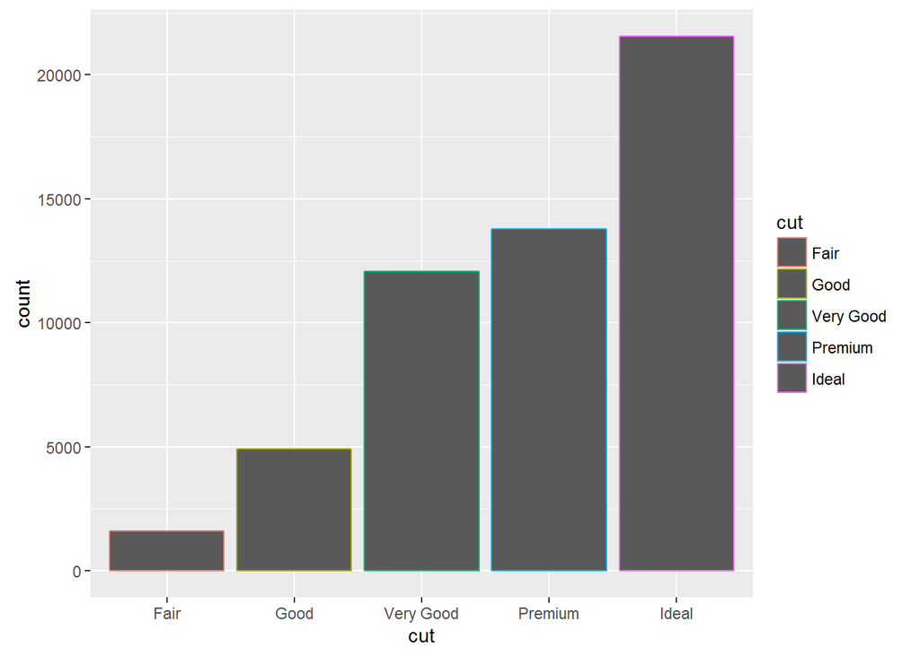

```r
#Adjusting how to display groups using colors
ggplot(data = diamonds) +
  geom_bar(mapping = aes(x = cut, colour = cut))
```

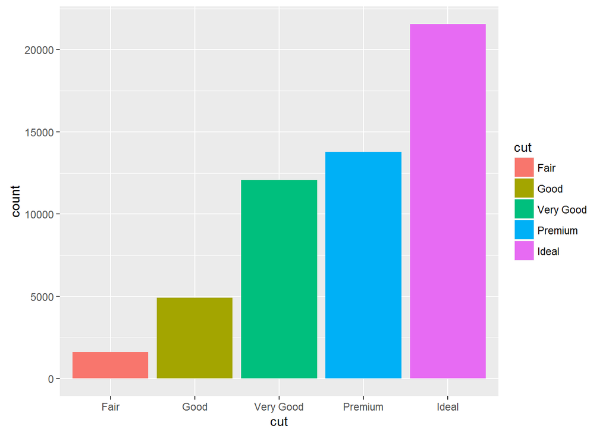

```r
ggplot(data = diamonds) +
  geom_bar(mapping = aes(x = cut, fill = cut))
```

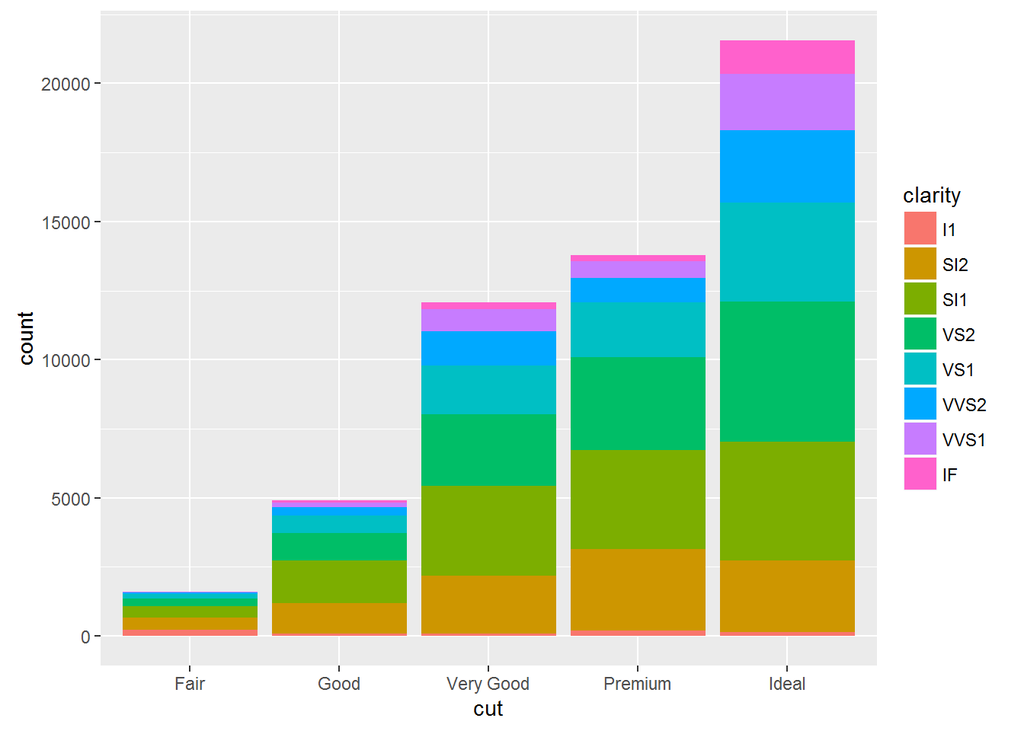

```r
ggplot(data = diamonds) +
  geom_bar(mapping = aes(x = cut, fill = clarity))
```

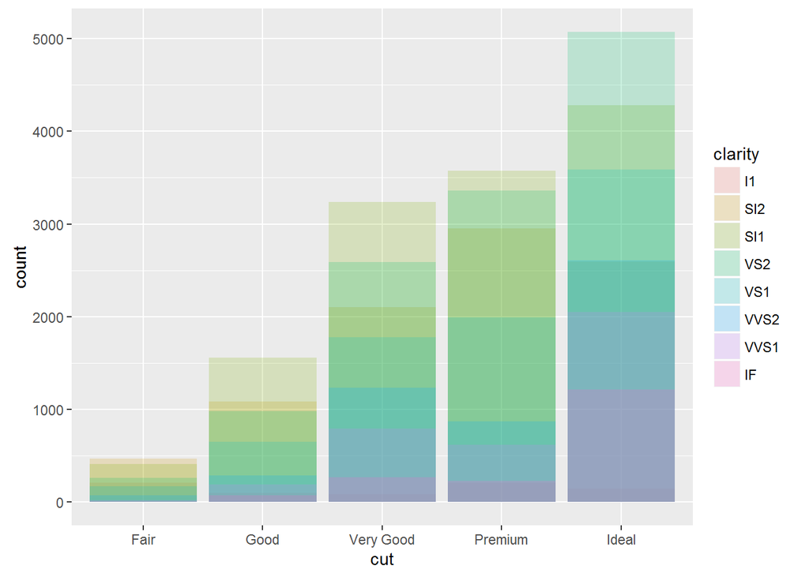

```r
ggplot(data = diamonds, mapping = aes(x = cut, fill = clarity)) +
  geom_bar(alpha = 1/5, position = "identity")
```

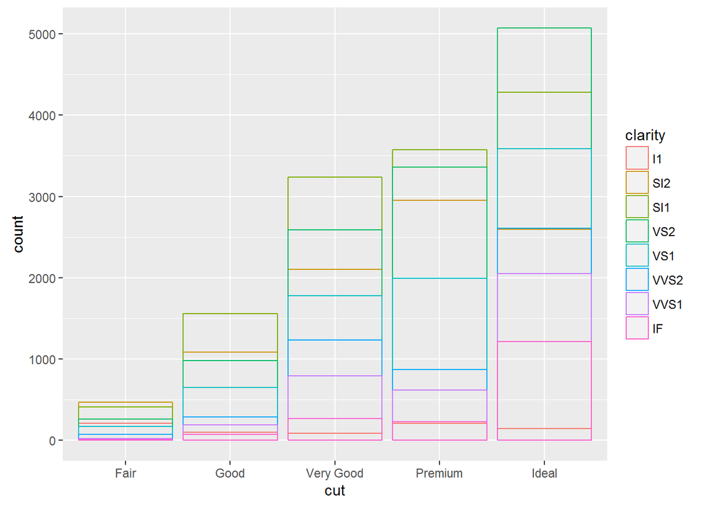

```r
ggplot(data = diamonds, mapping = aes(x = cut, colour = clarity)) +
  geom_bar(fill = NA, position = "identity")
```

## 9.2 Geom_bar

- position=“fill”: bar are stacked by group variable
- position=“dodge”: bar are separated horizontally by group

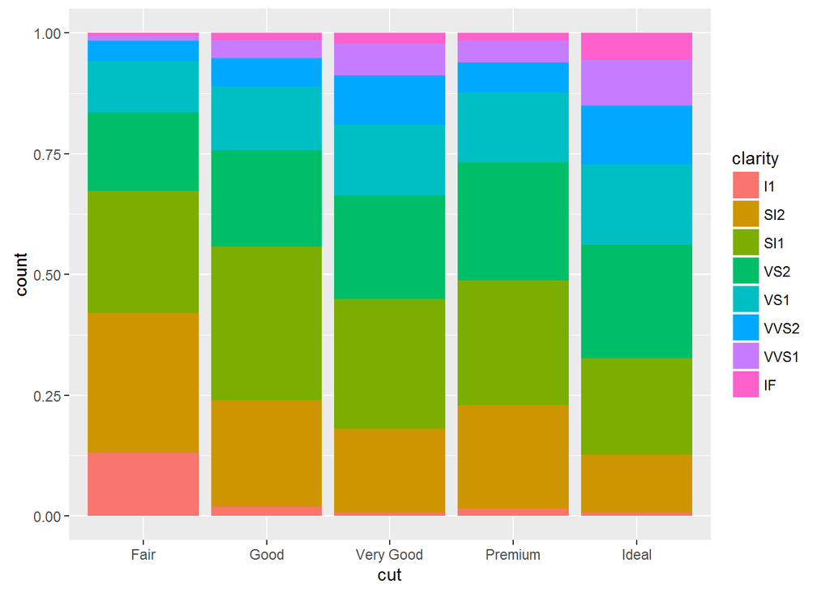

```r
#Bar same size
ggplot(data = diamonds) +
  geom_bar(mapping = aes(x = cut, fill = clarity), position = "fill")
```

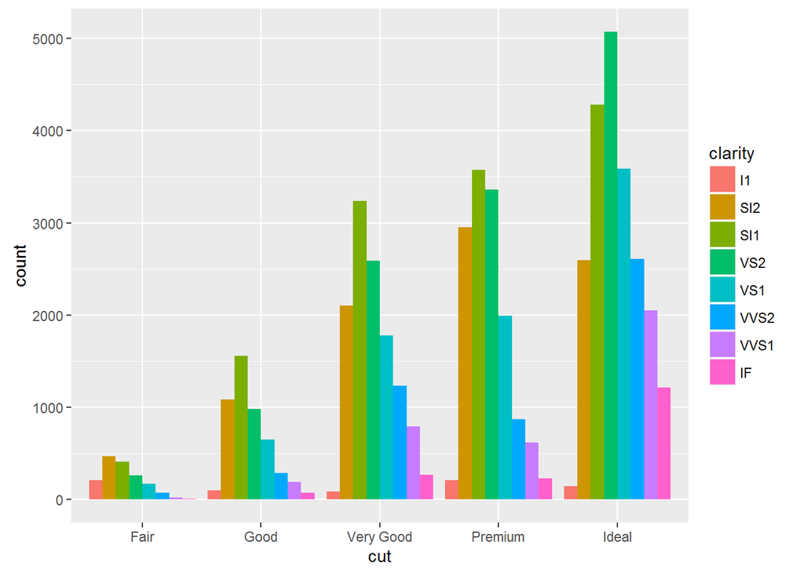

```r
#Bar horizontally splitted
ggplot(data = diamonds) +
  geom_bar(mapping = aes(x = cut, fill = clarity), position = "dodge")
```

# 10 Geom_point

Many points may overlap on the graph and thus to have a better visualization of the distribution, position=“jitter” instruction (as indicated below), adds a small noise to the data to allow to distinguish overlapping points.

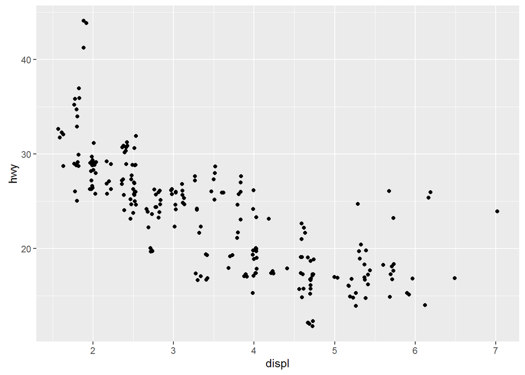

```r
#Adding noise to avoid data point rounding
ggplot(data = mpg) +
  geom_point(mapping = aes(x = displ, y = hwy), position = "jitter")
```

# 11 Coordinates

Reversing x and y-axis or to display the data using polar coordinated using coord_flip() and coord_polar() functions, respectively.

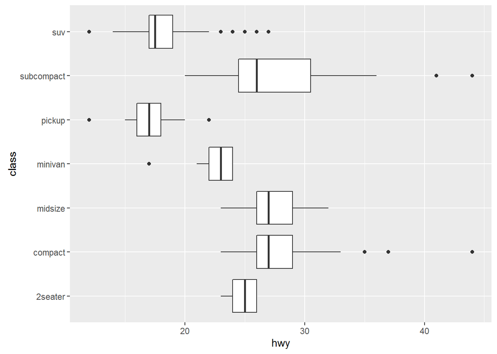

```r
#Change orientation of axis
ggplot(data = mpg, mapping = aes(x = class, y = hwy)) +
  geom_boxplot() +
  coord_flip()
```

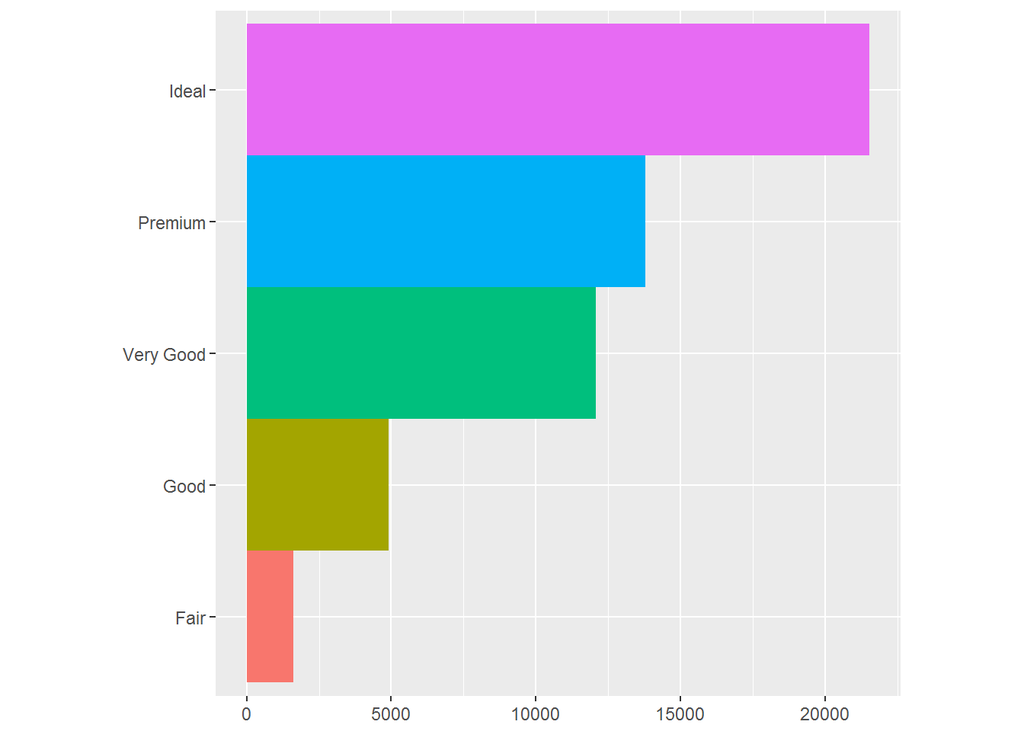

```r
#Polar coordinates
bar <- ggplot(data = diamonds) +
  geom_bar(
    mapping = aes(x = cut, fill = cut),
    show.legend = FALSE,
    width = 1
  ) +
  theme(aspect.ratio = 1) +
  labs(x = NULL, y = NULL)

bar + coord_flip()
```

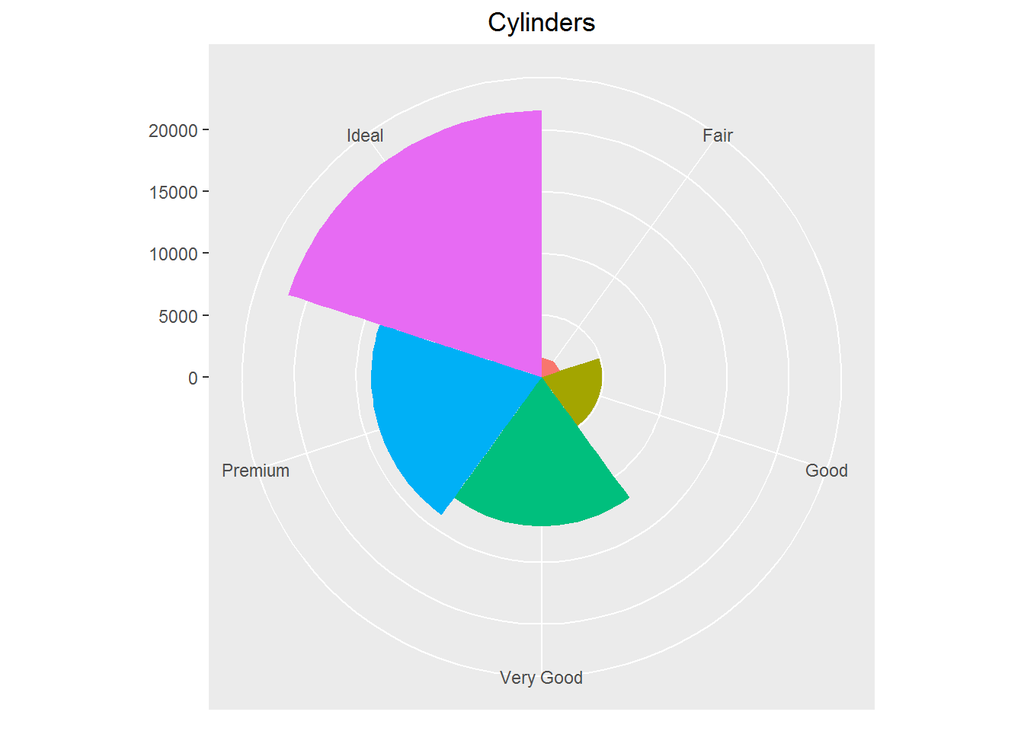

```r
bar + coord_polar(theta="x") + labs(title = "Cylinders")
```

# 12 Distribution

Density distribution can be plotted by setting y=..density.. into the aesthetic parameters.

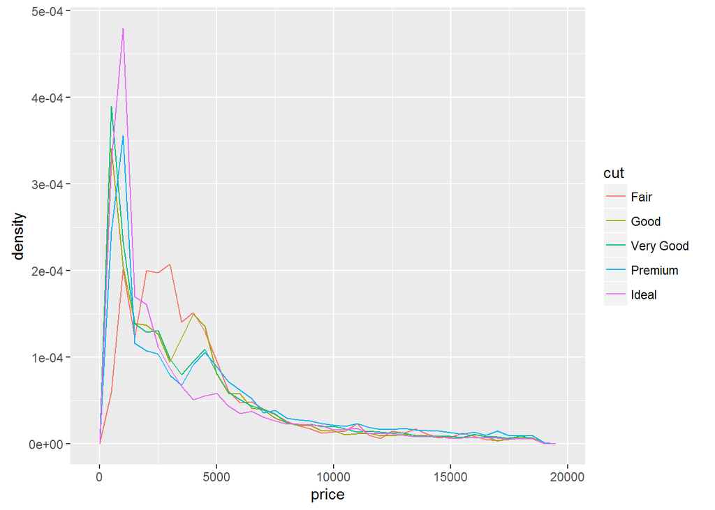

```r
#Setting density instead of count for freqpoly
ggplot(data = diamonds, mapping = aes(x = price, y = ..density..)) +
  geom_freqpoly(mapping = aes(colour = cut), binwidth = 500)
```

Boxplot can be reorder according to descriptive statistic values (median in the example below).

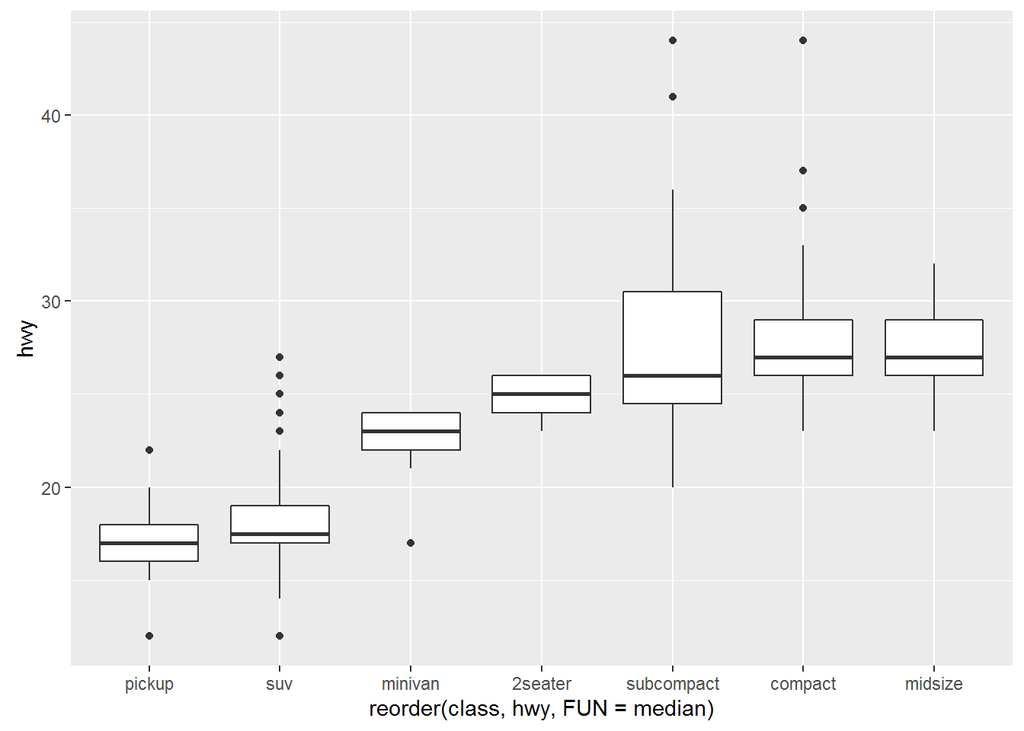

```r
#Reordering categorical variable order according to the median (FUN argument)
ggplot(data = mpg) +
  geom_boxplot(mapping = aes(x = reorder(class, hwy, FUN = median), y = hwy))
```

To display frequencies according to 2 categorical variables, two geoms are available:

- geom_tile(): data has to be processed beforehand using count function to calculate the frequencies in each group (color x cut in the example below)
- geom_bin2d()

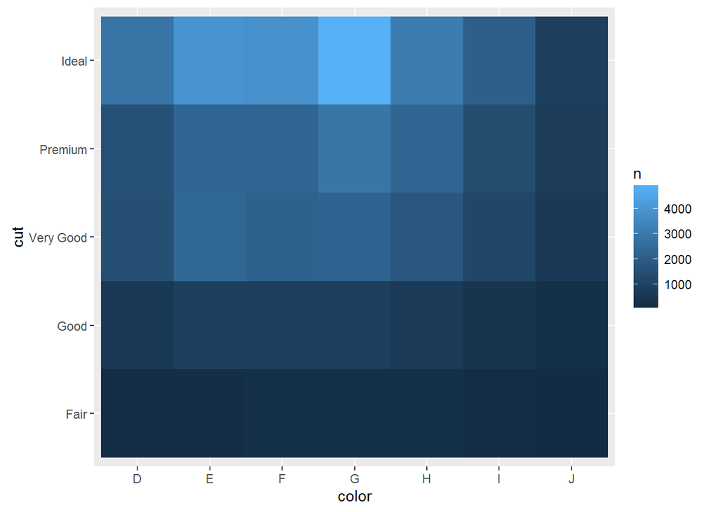

```r
#Visualising the count for 2 categorical variables
diamonds %>%
  count(color, cut) %>%
  ggplot(mapping = aes(x = color, y = cut)) +
    geom_tile(mapping = aes(fill = n))
```

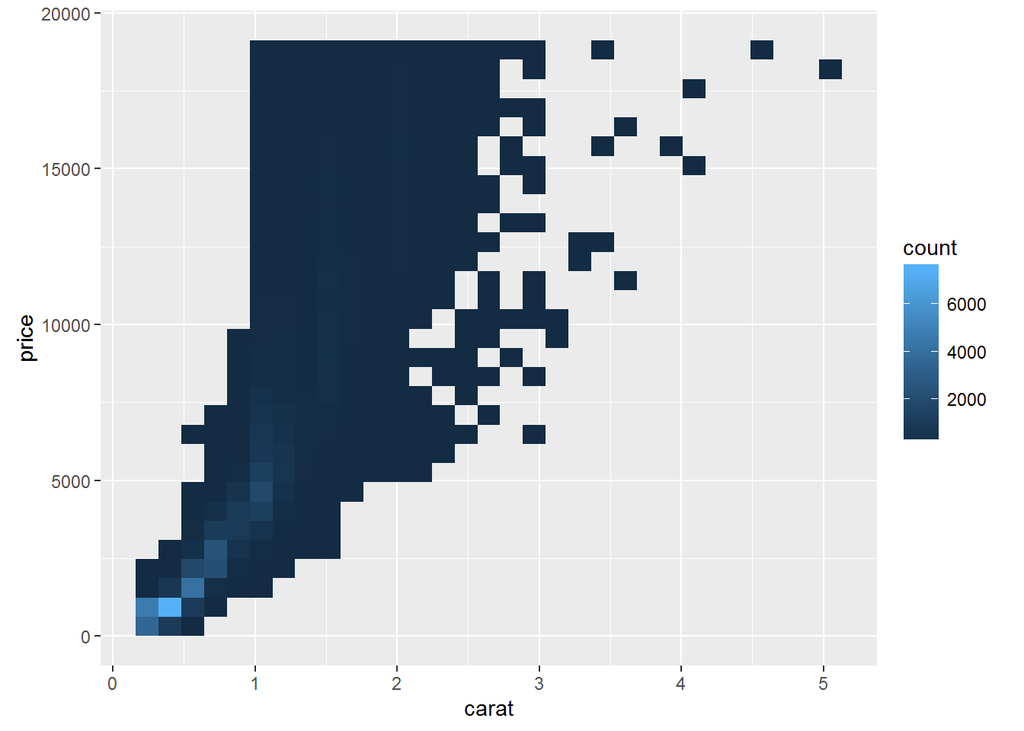

```r
#Creating 2d bins
ggplot(data = diamonds) +
  geom_bin2d(mapping = aes(x = carat, y = price))
```